# STAT 420: Homework 3

#### Solution:

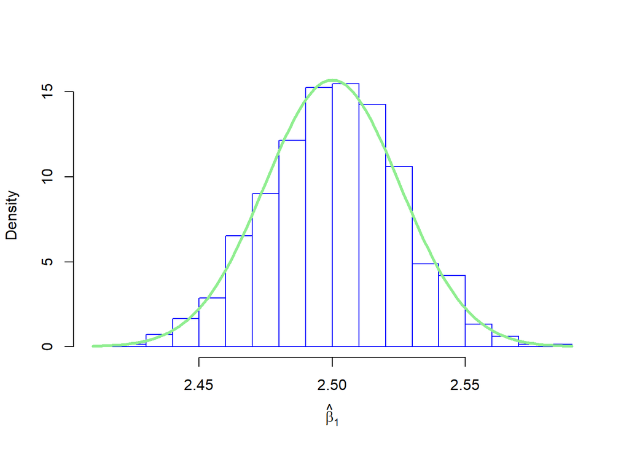

```r
hist(beta_1_hats, prob = TRUE, breaks = 20,
     xlab = expression(hat(beta)[1]),main = "", border = "blue")
curve(dnorm(x, mean = beta_1,sd = sqrt(var_beta_1_hat)),
      col = "light green", add = TRUE, lwd =3)
```

**(g)** Create a scatterplot of the $x$ values and the fitted $y$ values from the true model. Create $1500$ new samples of size `n = 60` from the model. Each time use `lm()` to fit a SLR model, and add the fitted regression line to the plot. (The points from your original scatterplot will not longer be visible, this is okay.) Add a final line that is thicker, and a different color, for the true model.

#### Solution:

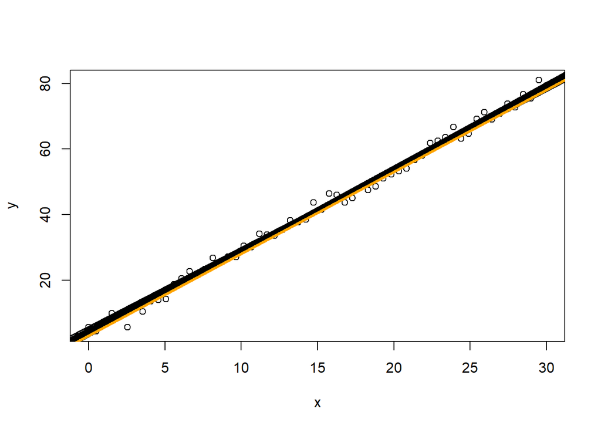

```r
plot(y~x)
for(i in 1:num_sample){
  eps = rnorm(n, mean = 0, sd=sigma)
  y = beta_0 +beta_1*x +eps
  sim_model = lm(y~x)
  abline(sim_model)
}
abline(3,2.5,col = "Orange", lwd=3)
```